Skip to contents

# Wrap a plot or image in submission chrome

Source: [`R/figure.R`](https://github.com/vthanik/tabular/blob/v0.3.2/R/figure.R)

Builds a figure display, the "F" in TFL. `figure()` takes a ggplot, a recorded base-R plot, a zero-argument drawing function, or a path to a PNG / JPG file, and surrounds it with the same canonical submission chrome as a table: up to four centred title lines, footnotes, and the per-page header / footer drawn from the active `preset()`. Pass a list to emit one figure per page in a single file.

## Usage

```r
figure(
  plot,
  titles = NULL,
  footnotes = NULL,
  width = NULL,
  height = NULL,
  halign = "center",
  valign = "middle",
  dpi = 300,
  meta = NULL
)
```

## Arguments

**plot**

*The figure to display.* One of: a `ggplot` object; a recorded base plot from `grDevices::recordPlot()`; a zero-argument function that draws to the active device when called; a length-1 path to a `.png`, `.jpg`, or `.jpeg` file; or a `list` of any of these for a multi-page figure.

**Tip:** a list may mix kinds freely — a ggplot, a recorded plot, and a PNG path can share one multi-page figure.

**titles**

*Title lines above the figure.* `<character> | NULL`. One element per line, up to four; same `{glue}` interpolation and `md()` / `html()` inline formatting as `tabular()`. `NULL` draws no titles.

**footnotes**

*Footnote lines below the figure.* `<character> | NULL`. One element per line; same interpolation and inline formatting as `titles`. `NULL` draws no footnotes.

**width**

*Drawn image width in inches.* `<numeric(1)> | NULL`. `NULL` fills the full printable width.

**height**

*Drawn image height in inches.* `<numeric(1)> | NULL`. `NULL` fills the body box height (the printable height minus the title and footnote chrome). Set a smaller value to leave vertical slack for `valign` to place the image within.

**halign**

*Horizontal placement in the content box.* `<character(1)>`. One of:

- `"left"`
- `"center"` (default)
- `"right"`

**valign**

*Vertical placement in the content box.* `<character(1)>`. One of:

- `"top"`
- `"middle"` (default)
- `"bottom"`

**Note:** continuous backends (HTML / Markdown) render the figure contained to the viewport with no fixed page height, so `valign` is a no-op there; the paged backends honour it exactly.

**dpi**

*Raster resolution for plot inputs.* `<numeric(1)>`. Resolution in dots per inch for PNG rasterisation. Ignored for file inputs (passed through unchanged) and for vector PDF targets.

**meta**

*Per-page token data frame.* `<data.frame> | NULL`. Multi-page only: one row per plot, whose columns become `{token}` values in that page's `titles` / `footnotes`. Ignored (with a warning) for a single-plot figure.

## Value

*A `figure_spec`.* Pass it to `emit()` to write a file, or print it to preview the figure inline.

## Details

**Two-axis placement.** By default the image FILLS the body content box — the full printable width by the box height (the printable height minus the title / footnote chrome). Pass an explicit `width` / `height` smaller than the box and `halign` / `valign` place the image within the resulting slack, independently — horizontally (`left` / `center` / `right`) and vertically (`top` / `middle` / `bottom`), both defaulting to centred. Paged backends (RTF / PDF / DOCX) honour `valign` exactly against the content-box height; with the box-filling default there is no vertical slack, so `valign` only bites once you set a shorter `height`. The continuous backends (HTML / Markdown) render the figure responsively, contained to the viewport, so `halign` still applies but `valign` is a no-op there.

**Format-aware rasterisation.** Plot inputs render to vector PDF for `.pdf` / `.tex` targets and to PNG at `dpi` for every other backend; file inputs pass through byte-for-byte. No raster work happens until `emit()`.

**Styling the chrome.** A figure carries the same chrome surfaces as a table, so `style()` and the `preset()` cosmetic knobs reach its titles, footnotes, and page header / footer — e.g. `style(fig, font_size = 14, .at = cells_title())` or `preset(fig, colors = list(footnotes = c(text = "grey40")))`. A figure has no body, column headers, or subgroup banner, so styling those surfaces is an error. Inter-section spacing follows the preset `spacing` knob (`title`, `footnote`), exactly like a table.

## See also

**Terminal verb:** `emit()` (write the figure to a file).

**Shared chrome:** `preset()` / `set_preset()` (page geometry, fonts, header / footer), `style()` (per-figure title / footnote / page-chrome styling), `tabular()` (the table sibling).

**Class predicate:** `is_figure_spec()`.

## Examples

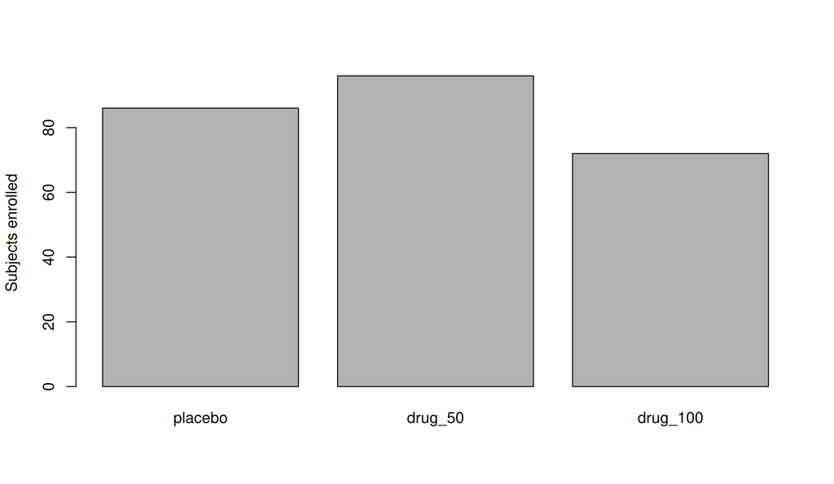

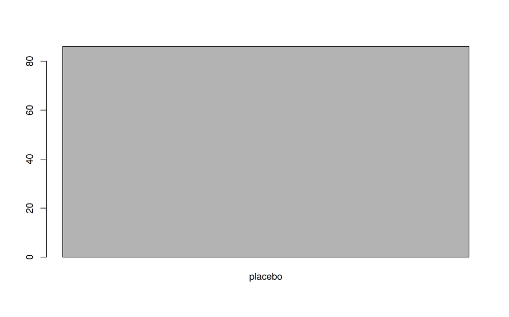

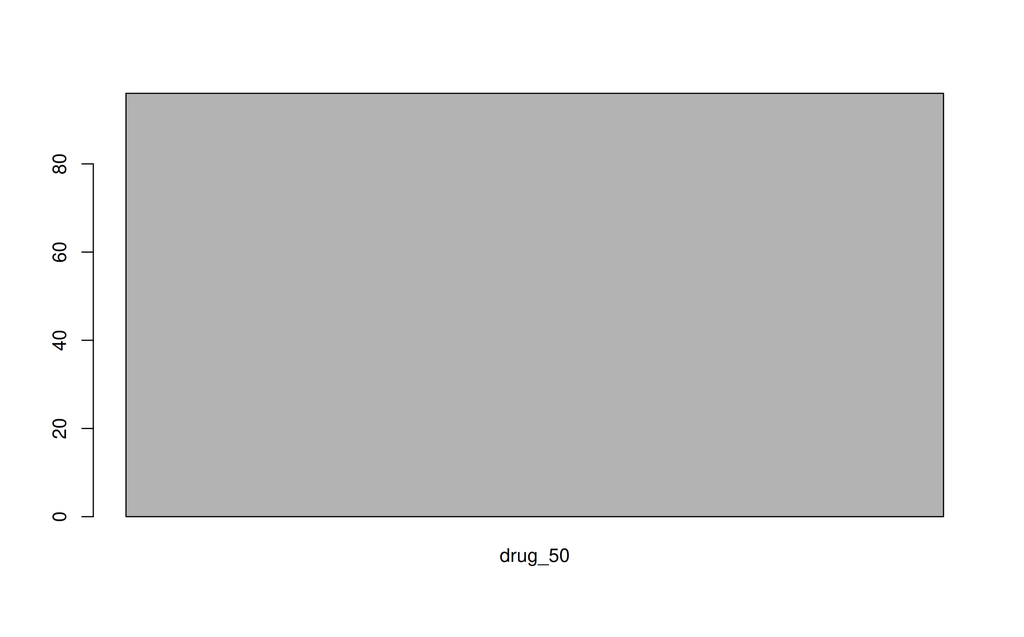

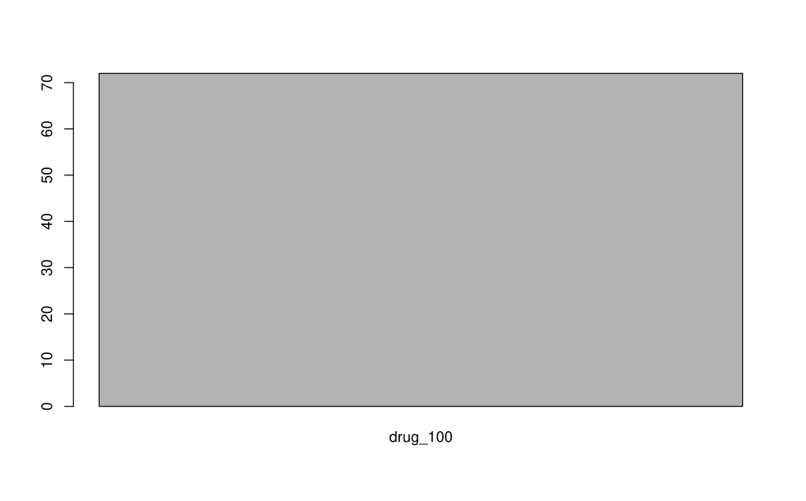

```r
# ---- Example 1: a single base-R figure with submission chrome ----
#
# A zero-argument drawing function is the simplest portable input: it
# draws to whatever device the backend opens. Here, subjects enrolled
# per treatment arm from the bundled BigN frame, wrapped in the
# canonical title block and a population footnote.
arms <- cdisc_saf_n[cdisc_saf_n$arm_short != "Total", ]

draw_enrollment <- function() {
  barplot(
    arms$n,
    names.arg = arms$arm_short,
    ylab = "Subjects enrolled",
    col = "grey70"
  )
}

fig <- figure(
  draw_enrollment,
  titles = c(
    "Figure 14.1.1",
    "Subjects Enrolled by Treatment Arm",
    "Safety Population"
  ),
  footnotes = "Total enrolled: N = 254."
)
fig

Figure 14.1.1
Subjects Enrolled by Treatment Arm
Safety Population



Total enrolled: N = 254.

# ---- Example 2: one figure per page from a list ----
#
# A list input emits one figure per page in a single file. Each arm
# gets its own page; the kinds may mix (a ggplot, a recorded plot, or
# a PNG path could share the list). Bottom-anchored here to show the
# two-axis placement.
draw_arm <- function(i) {
  force(i)
  function() {
    barplot(arms$n[i], names.arg = arms$arm_short[i], col = "grey70")
  }
}

per_arm <- figure(
  lapply(seq_len(nrow(arms)), draw_arm),
  titles = c("Figure 14.1.2", "Enrollment by Arm, One Page per Arm"),
  valign = "bottom"
)
per_arm

Figure 14.1.2
Enrollment by Arm, One Page per Arm
```